# BigQuery-Lecture 1

Author

Jae Jung

Published

February 21, 2026

# 1 SELECT / FROM / LIMIT

**Tip**

**What it does**: picks columns from a table and returns rows.

## 1.1 Sample Query

```sql
SELECT event_date, event_name
FROM `bigquery-public-data.ga4_obfuscated_sample_ecommerce.events_*`
LIMIT 1000;
```

## 1.2 Output

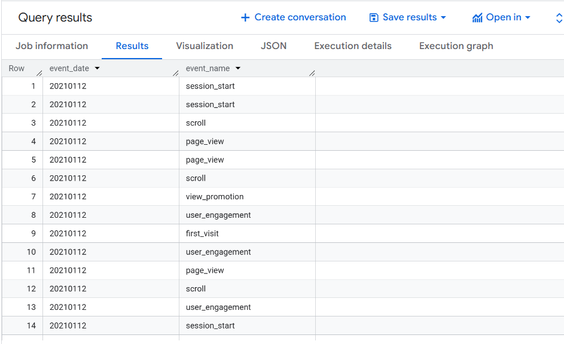

# 2 WHERE filters rows

**Note**

**What it does**: keeps only rows that match conditions.

## 2.1 Sample Query

> Task: Produce all the users who purchased on an event date

```sql
SELECT event_date, event_name, user_pseudo_id
FROM `bigquery-public-data.ga4_obfuscated_sample_ecommerce.events_*`
WHERE event_name = 'purchase'
LIMIT 100;
```

## 2.2 Output

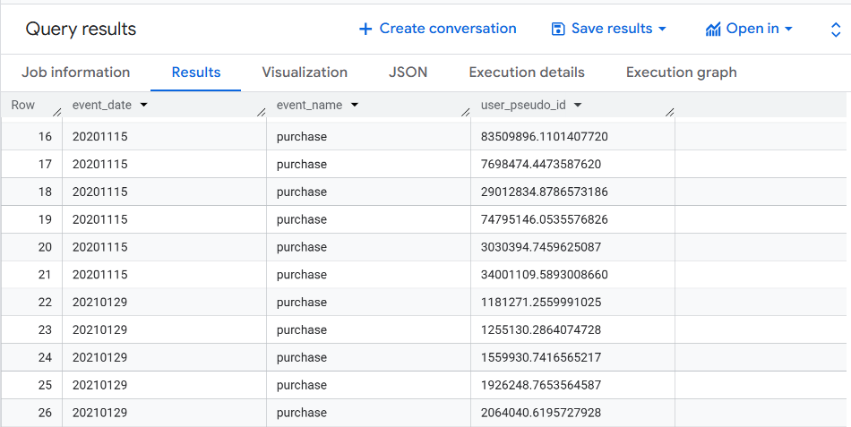

# 3 ORDER BY sorts results

**Tip**

**What it does**: sorts rows ascending/descending

## 3.1 Sample Query 1

> Purchases and dates in the order of recency from most recent to oldest event.

```sql
SELECT event_date, event_timestamp, event_name
FROM `bigquery-public-data.ga4_obfuscated_sample_ecommerce.events_*`
WHERE event_name = 'purchase'
ORDER BY event_timestamp DESC
LIMIT 20;
```

[figure not shown]

## 3.3 Sample Query 2

**Important**

**Tip for readability**: GA4 timestamps are microseconds

> **Task**: List all the events and associated time in descending order.

```sql
SELECT
  TIMESTAMP_MICROS(event_timestamp) AS event_time,
  event_name
FROM `bigquery-public-data.ga4_obfuscated_sample_ecommerce.events_*`
ORDER BY event_timestamp DESC
LIMIT 10;
```

## 3.4 Output 2

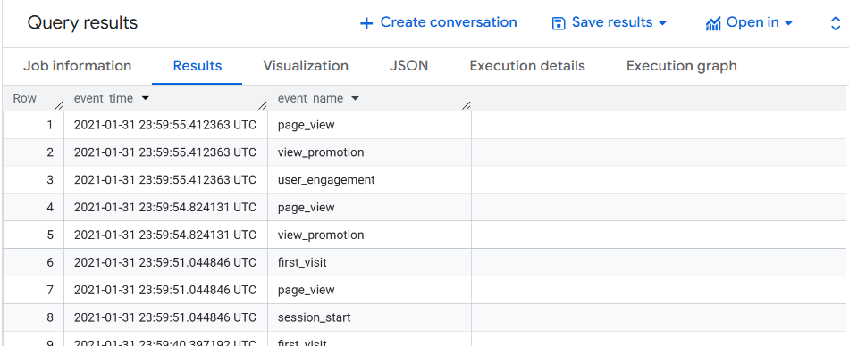

# 4 COUNT, SUM, AVG, MIN, MAX

**Tip**

**What they do**: summarize many rows into a few values.

## 4.1 Sample Query 1

> **Task:** Count total events in a date range. That is, what is the number of events in the month of December 2020?

```sql
SELECT COUNT(*) AS event_count
FROM `bigquery-public-data.ga4_obfuscated_sample_ecommerce.events_*`
WHERE _TABLE_SUFFIX BETWEEN '20201201' AND '20201231';
```

## 4.2 Output 1

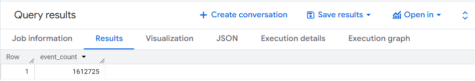

## 4.3 Sample Query 2

> **Task**: Count purchases in a date range

```sql
SELECT COUNT(*) AS purchase_events
FROM `bigquery-public-data.ga4_obfuscated_sample_ecommerce.events_*`
WHERE event_name = 'purchase'
    AND _TABLE_SUFFIX BETWEEN '20201201' AND '20201231';
```

> **Task**: What is the number of all the purchases made during December 2020.

## 4.4 Output 2

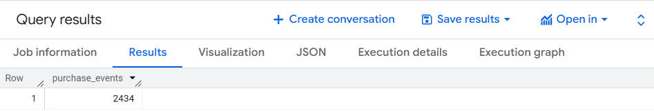

# 5 GROUP BY controls the grain

**Note**

**What it does**: defines what one row in your result represents (e.g., per day, per event_name, per user).

## 5.1 Sample Query 1

> **Task**: List event date and event counts by event date in ascending order for December 2020.

```sql
-- Events by day
SELECT event_date, COUNT(*) AS events
FROM `bigquery-public-data.ga4_obfuscated_sample_ecommerce.events_*`
WHERE _TABLE_SUFFIX BETWEEN '20201201' AND '20201231'
GROUP BY event_date
ORDER BY event_date;
```

## 5.2 Output 1

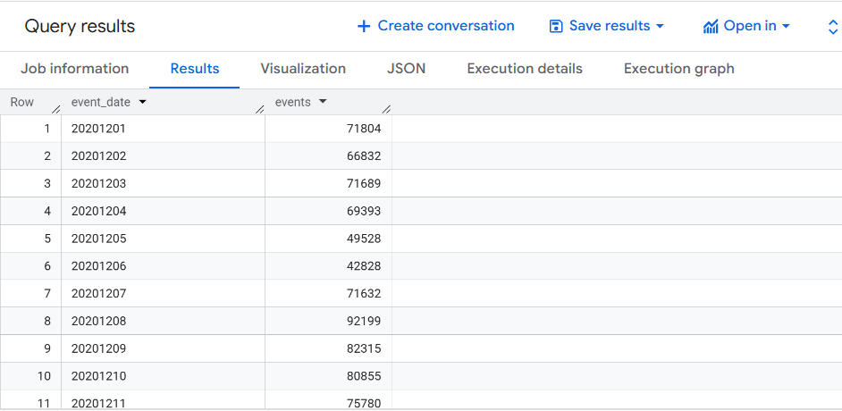

## 5.3 Sample Query 2

> **Task**: List top 15 event names and their counts by the event counts.

```sql
-- Top event types
SELECT event_name, COUNT(*) AS events
FROM `bigquery-public-data.ga4_obfuscated_sample_ecommerce.events_*`
WHERE _TABLE_SUFFIX BETWEEN '20201201' AND '20201231'
GROUP BY event_name
ORDER BY events DESC
LIMIT 15;
```

## 5.4 Output 2

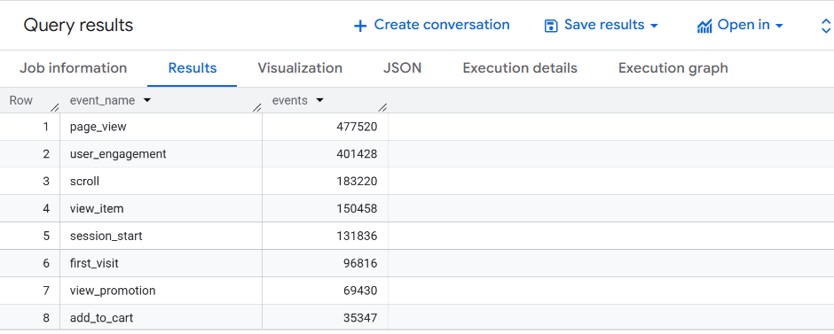

# 6 HAVING filters after grouping

**Tip**

**What it does**: filters aggregated results (after GROUP BY).

## 6.1 Sample Query

> **Task**: List all the events and associated event counts greater than 50,000 in descending order of event counts.

```sql
-- Only event types with at least 50,000 events
SELECT event_name, COUNT(*) AS events
FROM `bigquery-public-data.ga4_obfuscated_sample_ecommerce.events_*`
WHERE _TABLE_SUFFIX BETWEEN '20201201' AND '20201231'
GROUP BY event_name
HAVING COUNT(*) >= 50000
ORDER BY events DESC;
```

## 6.2 Output

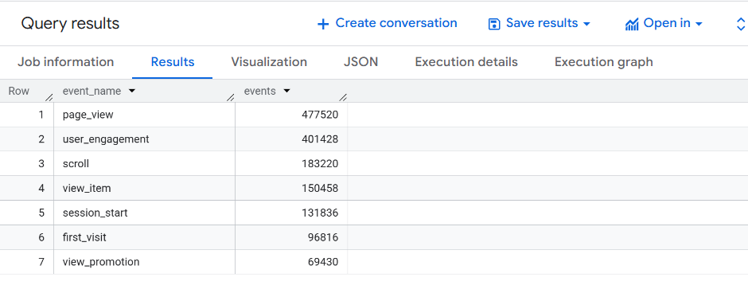

# 7 Wildcard tables + _TABLE_SUFFIX

**Note**

**What it does**: events_* queries many days, and _TABLE_SUFFIX limits which days you scan (faster/cheaper).

## 7.1 Query

> **Task**: Event counts by event date for the first 7 days of December, 2020.

```sql
SELECT event_date, COUNT(*) AS events
FROM `bigquery-public-data.ga4_obfuscated_sample_ecommerce.events_*`
WHERE _TABLE_SUFFIX BETWEEN '20201201' AND '20201207'
GROUP BY event_date
ORDER BY event_date;
```

## 7.2 Output

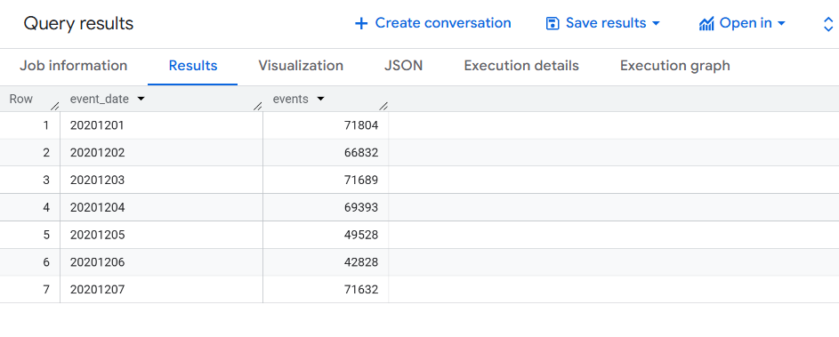